# Compare ESTIMATE results to consensus cell types

Stephanie J. Spielman

2025-02-25

The purpose of this notebook is to compare ESTIMATE scores to consensus cell types, which were identified in [this `OpenScPCA-nf` pipeline module](https://github.com/AlexsLemonade/OpenScPCA-nf/tree/bc147c0ded5460db30a8ebbaf7854eb2f47e386d/modules/cell-type-consensus).

## Setup

```r
renv::load()

library(ggplot2)
theme_set(theme_bw())
options(readr.show_col_types = FALSE)
```

### Paths

```r
data_dir <- here::here("analysis", "estimate", "data")
celltype_dir <- file.path(data_dir, "consensus-celltypes")

library_metadata_file <- here::here("s3_files", "scpca-library-metadata.tsv")
estimate_file <- here::here("analysis", "estimate", "results", "estimate_results.tsv")
immune_celltypes_groups_url <- "https://raw.githubusercontent.com/AlexsLemonade/OpenScPCA-analysis/refs/heads/main/analyses/cell-type-consensus/references/consensus-immune-cell-types.tsv"


# we'll name these by library id to start, and then swap to sample later
celltype_files <- list.files(
  celltype_dir,
  pattern = "_processed_consensus-cell-types\\.tsv\\.gz$",
  full.names = TRUE,
  recursive = TRUE
) |>
    purrr::set_names(
    \(x) {stringr::str_split_i(basename(x), pattern = "_", i = 1)}
  )
```

```r
# define low-quality samples as identified in https://github.com/AlexsLemonade/scpca-paper-figures/issues/135
low_quality_samples <- c(
  "SCPCS000003",
  "SCPCS000030",
  "SCPCS000040",
  "SCPCS000178",
  "SCPCS000191",
  "SCPCS000197",
  "SCPCS000203",
  "SCPCS000608"
)
```

### Read input data

```r
estimate_df <- readr::read_tsv(estimate_file)
library_metadata_df <- readr::read_tsv(library_metadata_file)

id_df <- estimate_df |>
  dplyr::inner_join(
    library_metadata_df |>
      dplyr::filter(seq_unit %in% c("cell", "nucleus")) |>
      dplyr::select(scpca_sample_id, scpca_library_id),
    by = c("sample_id" = "scpca_sample_id")
  ) |>
  dplyr::select(project_id, sample_id, library_id = scpca_library_id) |>
  dplyr::distinct()

library_sample_c <- id_df$sample_id |>
  purrr::set_names(id_df$library_id)

celltype_data <- celltype_files |>
  # only keep libraries of interest
  purrr::keep_at(
    \(library_id) library_id %in% names(library_sample_c)
  ) |>
  purrr::map(
    \(f) {
      readr::read_tsv(f) |>
        dplyr::select(project_id, sample_id, consensus_annotation, consensus_ontology)
  })

# update names to sample ids
sample_names <- library_sample_c[names(celltype_data)] |> unname()
names(celltype_data) <- sample_names

immune_df <- readr::read_tsv(immune_celltypes_groups_url)
```

### Define cell type groups

The first step is to group consensus cell types into “immune” and “stromal” categories to enable comparisons with ESTIMATE scores.

Let’s first look at what the consensus cell types that we have for this data are. For human readability, we’ll look at the annotations, not ontologies, for this.

```r
all_celltypes <- celltype_data |>
  purrr::map(
    \(cell_df) dplyr::pull(cell_df, consensus_annotation) |> unique()
  ) |>
  purrr::reduce(union)

# print in alphabetical order
sort(all_celltypes)
```

```
 [1] "adipocyte"                       "astrocyte"
 [3] "B cell"                          "blood vessel endothelial cell"
 [5] "CD4-positive, alpha-beta T cell" "chondrocyte"
 [7] "dendritic cell"                  "endothelial cell"
 [9] "epithelial cell"                 "fibroblast"
[11] "glial cell"                      "granulocyte"
[13] "innate lymphoid cell"            "lymphocyte of B lineage"
[15] "macrophage"                      "mature alpha-beta T cell"
[17] "mature B cell"                   "mature T cell"
[19] "megakaryocyte"                   "memory B cell"
[21] "memory T cell"                   "mesangial cell"
[23] "monocyte"                        "mononuclear phagocyte"
[25] "muscle cell"                     "myeloid leukocyte"
[27] "naive B cell"                    "natural killer cell"
[29] "neuron"                          "neuron associated cell"
[31] "neutrophil"                      "pericyte"
[33] "plasma cell"                     "regulatory T cell"
[35] "smooth muscle cell"              "stem cell"
[37] "stromal cell"                    "T cell"
[39] "Unknown"
```

```
adipocyte
astrocyte
B cell
blood vessel endothelial cell
CD4-positive, alpha-beta T cell
chondrocyte
dendritic cell
endothelial cell
epithelial cell
fibroblast
glial cell
granulocyte
innate lymphoid cell
lymphocyte of B lineage
macrophage
mature alpha-beta T cell
mature B cell
mature T cell
megakaryocyte
memory B cell
memory T cell
mesangial cell
monocyte
mononuclear phagocyte
muscle cell
myeloid leukocyte
naive B cell
natural killer cell
neuron
neuron associated cell
neutrophil
pericyte
plasma cell
regulatory T cell
smooth muscle cell
stem cell
stromal cell
T cell
Unknown
```

- We can use the `immune_df` data frame to identify immune cell types to use in comparisons
- Since ESTIMATE defines stromal as non-cancer and non-immune (aka “everything else”), we’ll define all non-immune and non-neural cell types as stromal cells
  - An important caveat to bear in mind that is that two of our projects, SCPCP000006 (Wilms tumor) and SCPCP000017 (osteosarcoma), will have cancer cell types with a high degree of similarity to several stromal cell types, which can make teasing these categories apart challenging. This is particularly relevant for mesangial cells in SCPCP000006; we are classifying these cell types as “stromal” but they may be highly similar to the cancer cells in those samples

```r
stromal_celltypes <- c(
  "chondrocyte",
  "adipocyte",
  "endothelial cell",
  "epithelial cell",
  "smooth muscle cell",
  "muscle cell",
  "blood vessel endothelial cell",
  "stromal cell",
  "pericyte",
  "mesangial cell",
  "fibroblast"
)

immune_celltypes <- immune_df$consensus_annotation
```

The following consensus cells are *not* currently considered in either the immune or bulk group.

```r
other_celltypes <- all_celltypes[!(all_celltypes %in% c(stromal_celltypes, immune_celltypes))]
sort(other_celltypes)
```

```
[1] "astrocyte"              "glial cell"             "neuron"
[4] "neuron associated cell" "stem cell"              "Unknown"
```

```
astrocyte
glial cell
neuron
neuron associated cell
stem cell
Unknown
```

Next, we’ll calculate proportions of these cell types across samples.

```r
celltype_category_df <- celltype_data |>
  purrr::map(
    \(cell_df) {
        cell_df |>
        dplyr::mutate(
          estimate_category = dplyr::case_when(
            consensus_annotation %in% immune_celltypes ~ "immune",
            consensus_annotation %in% stromal_celltypes ~ "stromal",
            .default = "other"
          )) |>
        dplyr::count(estimate_category) |>
        dplyr::mutate(frac = n/sum(n)) |>
        dplyr::select(-n)
    }
  ) |>
  purrr::list_rbind(names_to = "sample_id") |>
  # we need to add in project ids
  dplyr::inner_join(dplyr::select(id_df, project_id, sample_id)) |>
  dplyr::mutate(
    estimate_category = forcats::fct_relevel(estimate_category, "other", "stromal", "immune"),
    # add indicator for sample quality
    sample_quality = ifelse(
      sample_id %in% low_quality_samples,
      "low-quality", "acceptable quality"
    )
  )
```

We’ll look at the distributions of cell groups here. In this plot, we’ll also add boxes around samples that have been [previously identified](https://github.com/AlexsLemonade/scpca-paper-figures/blob/90563f229910042f501576752992296de8925986/analysis/pseudobulk-bulk-prediction/notebooks/build-assess-models.Rmd#L41-L53) as low-quality.

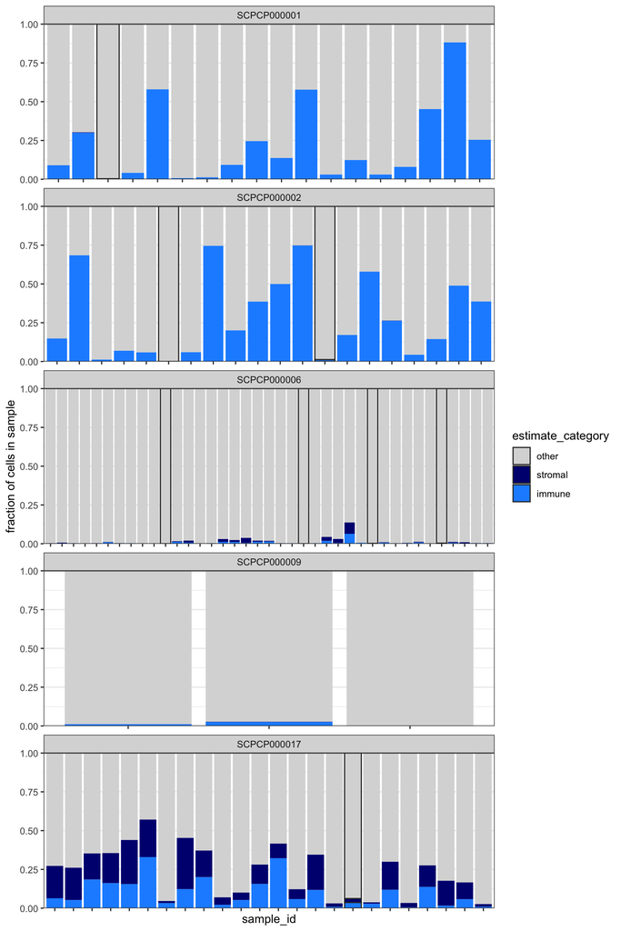

```r
ggplot(celltype_category_df) +
  aes(x = sample_id, y = frac, fill = estimate_category, linewidth = sample_quality) +
  geom_col(color = "grey20") +
  scale_linewidth_manual(values = c(0.001, 0.5), guide = "none") +
  # bright color to help make stromal more visible
  scale_fill_manual(values = c("gray85", "navy", "dodgerblue")) +
  facet_wrap(vars(project_id), scales = "free", ncol = 1) +
  scale_y_continuous(expand = c(0,0)) +
  labs(y = "fraction of cells in sample") +
  theme(axis.text.x = element_blank())
```

Outlined bars represent low-quality samples. These tend to have low immune and stromal fractions and very high “other” fractions, but they are not unique in this regard.

## Relationship between cell types and ESTIMATE scores

Next, we’ll directly look at the relationships between fractions of these cell type groups and ESTIMATE scores. We’ll do this comparison with both bulk- and pseudobulk-derived ESTIMATE scores.

Low-quality samples are shown as open points, and samples of acceptable quality are shown as closed points.

```r
wide_category_df <- celltype_category_df |>
  dplyr::mutate(estimate_category = glue::glue("celltype_{estimate_category}")) |>
  tidyr::pivot_wider(
    names_from = estimate_category,
    values_from = frac,
    values_fill = 0
  )

combined_wide_df <- estimate_df |>
  dplyr::filter(expression_type != "bulk_tpm") |>
  dplyr::mutate(score_type = glue::glue("estimate_score_{score_type}")) |>
   tidyr::pivot_wider(
    names_from = score_type,
    values_from = score
  ) |>
  dplyr::left_join(wide_category_df)
```

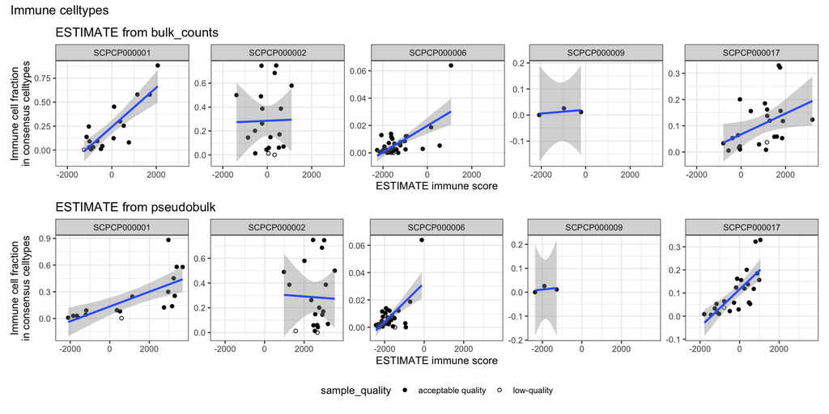

```r
# Use patchwork to plot to preserve the axis ranges in each expression type
unique(combined_wide_df$expression_type) |>
  purrr::map(
    \(type) {
      combined_wide_df |>
        dplyr::filter(expression_type == type) |>
        ### plot
        ggplot() +
        aes(x = estimate_score_immune, y = celltype_immune) +
        geom_point(aes(shape = sample_quality)) +
        scale_shape_manual(values = c(19, 21)) +
        geom_smooth(method = "lm") +
        facet_wrap(vars(project_id), scales = "free_y", nrow = 1) +
        labs(
          title = glue::glue("ESTIMATE from {type}"),
          x = "ESTIMATE immune score",
          y = "Immune cell fraction\nin consensus celltypes"
        ) +
        theme(legend.position = "bottom")
    }
  ) |>
  patchwork::wrap_plots(
    nrow = 2,
    guides="collect",
    axis_title="collect"
  ) +
  patchwork::plot_annotation(title = "Immune celltypes") & theme(legend.position = "bottom")
```

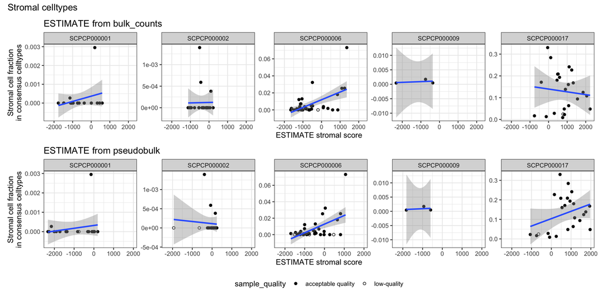

```r
# Use patchwork to plot to preserve the axis ranges in each expression type
unique(combined_wide_df$expression_type) |>
  purrr::map(
    \(type) {
      combined_wide_df |>
        dplyr::filter(expression_type == type) |>
        ### plot
        ggplot() +
        aes(x = estimate_score_stromal, y = celltype_stromal) +
        geom_point(aes(shape = sample_quality)) +
        scale_shape_manual(values = c(19, 21)) +
        geom_smooth(method = "lm") +
        facet_wrap(vars(project_id), scales = "free_y", nrow = 1) +
        labs(
          title = glue::glue("ESTIMATE from {type}"),
          x = "ESTIMATE stromal score",
          y = "Stromal cell fraction\nin consensus celltypes"
        ) +
        theme(legend.position = "bottom")
    }
  ) |>
  patchwork::wrap_plots(
    nrow = 2,
    guides="collect",
    axis_title="collect"
  ) +
  patchwork::plot_annotation(title = "Stromal celltypes") & theme(legend.position = "bottom")
```

- Immune plots:
  - SCPCP000001, SCPCP00006 (although possibly outlier-driven), and SCPCP000017 show a positive relationship between quantities for both modalities
  - There is no apparent relationship for SCPCP000002 or SCPCP000009
  - Most, but not all, low-quality samples tend to to fall outside the given project’s confidence interval (CI)
- Stromal plots:
  - SCPCP00006 shows a positive relationship between quantities for both modalities
    - Again, SCPCP000006 has an outlier point that may be driving some/much of the observed positive relationship
  - There is no apparent relationship for the other projects, in either modality
  - Again, we emphasize that these stromal scores may be less informative than the immune scores due to additional challenges distinguishing cancer cells from stromal cells

### Relationship between other cell types and tumor purity

In theory, the `Unknown` cells in our consensus annotation are more likely to be tumor cells. We also excluded several cell types from analysis which might also be tumor. Similarly in theory, the ESTIMATE score (sum of immune and stromal) is expected to be proportional to tumor purity where higher ESTIMATE scores correspond to lower tumor purity. Therefore we expect there to be a negative correlation between fractions of cells that are non-immune/non-stromal and the ESTIMATE score.

Is there a relationship between these quantities?

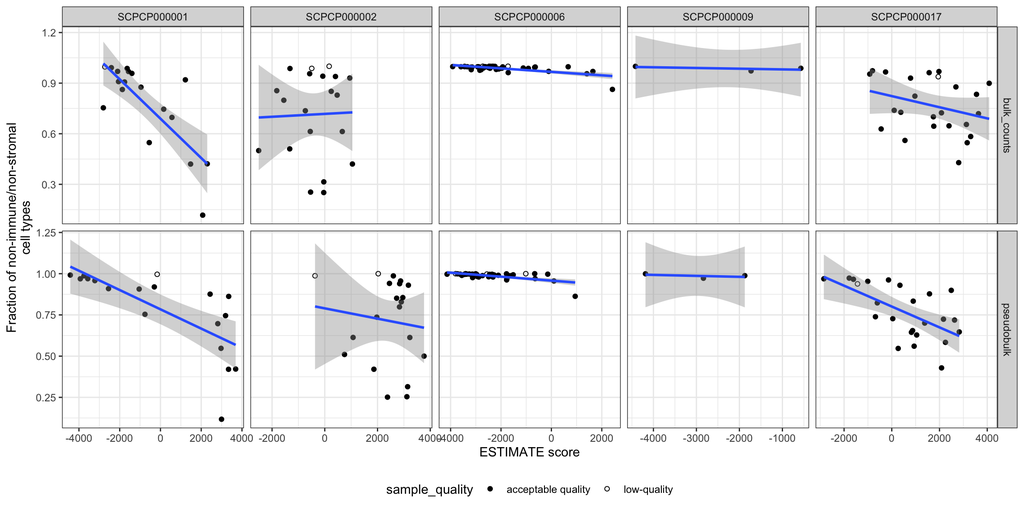

```r
unknown_df <- celltype_data |>
  purrr::map(
    \(cell_df) {
        cell_df |>
          # group to keep these columns
          dplyr::group_by(sample_id, project_id) |>
          dplyr::summarize(
            is_unknown = sum(consensus_annotation %in% other_celltypes),
            frac_unknown = is_unknown / dplyr::n()
          )
    }
  ) |>
  purrr::list_rbind(names_to = "sample_id") |>
  dplyr::inner_join(combined_wide_df) |>
  dplyr::mutate(estimate_score = estimate_score_stromal + estimate_score_immune)

ggplot(unknown_df) +
  aes(x = estimate_score, y = frac_unknown) +
  geom_point(aes(shape = sample_quality)) +
  scale_shape_manual(values = c(19, 21)) +
  geom_smooth(method = "lm") +
  facet_grid(
    rows = vars(expression_type),
    cols = vars(project_id),
    scales = "free"
  ) +
  labs(
    x = "ESTIMATE score",
    y = "Fraction of non-immune/non-stromal\ncell types"
  ) +
  theme(legend.position = "bottom")
```

There appears to be a negative relationship for SCPCP000001 and SCPCP000017, a very weak negative relationship for SCPCP000006 (possibly outlier driven?), and no relationship for SCPCP000002 or SCPCP000009. This is consistent between modalities.

While it’s nice to see some negative correlations here, the lack of robust negative relationship may indicate that:

- Genes included in ESTIMATE do not comprehensively capture all non-cancer genes
- Genes included in ESTIMATE are highly expressed in some of our tumor cells
- Stromal cells are hard to distinguish from tumor

### All projects together

We’ll next visualize the same results, but pooling all projects together and with correlation coefficients (both $R$ and $\rho$). We’ll also color points based on whether the pseudobulk was derived from single-cell or single-nuclei experiment.

For these statistics and plots, we’ll *remove* low-quality samples entirely.

Again, note that the score shown in the the third plot with the “other” celltypes is the ESTIMATE score, which is the sum of stromal and immune, and is expected to negatively correlate with tumor purity.

```r
# Helper function to make scatterplots showing correlation coefficients
make_scatterplot <- function(combined_wide_df, estimate_col, celltype_col, type, annotate_x, annotate_y) {
  r <- cor(combined_wide_df[[estimate_col]], combined_wide_df[[celltype_col]]) |> round(2)
  rho <- cor(combined_wide_df[[estimate_col]], combined_wide_df[[celltype_col]], method = "spearman") |> round(2)

  plot_df <- combined_wide_df |>
    dplyr::select(all_of(c(estimate_col, celltype_col, "seq_unit")))
  colnames(plot_df) <- c("estimate", "celltype", "seq_unit")

  ggplot(plot_df) +
    aes(x = estimate, y = celltype) +
    geom_point(aes(color = seq_unit)) +
    scale_shape_manual(values = c(16, 21)) +
    geom_smooth(method = "lm") +
    labs(
      title = glue::glue("{type} celltypes"),
      x = glue::glue("ESTIMATE {type} score"),
      y = glue::glue("{type} cell fraction\nin consensus celltypes")
    ) +
    annotate(
      geom = "text",
      x = annotate_x,
      y = annotate_y,
      label = glue::glue("R = {r}\nRho = {rho}")
    ) +
  theme(legend.position = "bottom")
}
```

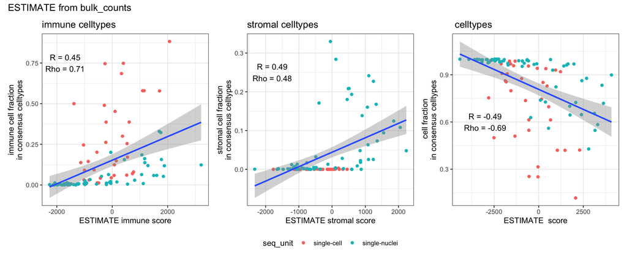

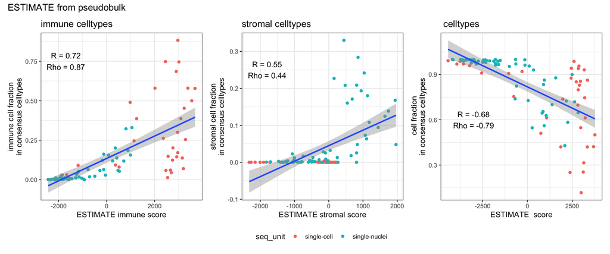

```r
combined_wide_df <- combined_wide_df |>
  dplyr::filter(sample_quality == "acceptable quality") |>
  dplyr::mutate(
    seq_unit = ifelse(
      project_id %in% c("SCPCP000001", "SCPCP000002"),
      "single-cell",
      "single-nuclei"
    ),
    estimate_score = estimate_score_stromal + estimate_score_immune
  )

unique(combined_wide_df$expression_type) |>
  purrr::map(
    \(type) {

      plot_df <- combined_wide_df |>
        dplyr::filter(expression_type == type)

      patchwork::wrap_plots(
        make_scatterplot(plot_df, "estimate_score_immune", "celltype_immune", "immune", -1700, 0.75),
        make_scatterplot(plot_df, "estimate_score_stromal", "celltype_stromal", "stromal", -1800, 0.25),
        make_scatterplot(plot_df, "estimate_score", "celltype_other", "", -3000, 0.6),
        guides = "collect"
      ) +
        patchwork::plot_annotation(title = glue::glue("ESTIMATE from {type}")) & theme(legend.position = "bottom")
    }
  )
```

- We see the same trends for comparisons with both bulk and pseudobulk ESTIMATE scores, although the correlations are somewhat weaker when measured from bulk data.
- We see a strong positive correlation for immune cell fractions and the ESTIMATE immune score.
  - This agreement between methods suggests that we have done a reasonable job capturing immune cells with our consensus labels
  - For pseudobulk, we also see a separation of points where the single-cell samples usually have higher immune fractions/scores compared to single-nuclei samples, which is consistent with our expectations for these sequencing units within that modality.
- We see a positive, but somewhat weaker, relationship for stromal, and virtually all of the variation in stromal *cell type fractions* is from the single-nuclei samples
- We see a negative but still decent correlation for other cell fractions and the ESTIMATE score, which is consistent with expectations but given challenges of distinguishing between stromal and tumor, we don’t expect this correlation to be exceptionally strong